# Sanitation and Global Health

#### Dalla visualizzazione di questa tabella è possibile osservare come in media, la percentuale più alta della popolazione delle varie nazioni, sia che utilizzino servizi sanitari di base, sia che utilizzino servizi gestiti in più sicurezza, appartiene alla classe urbana (e non a quella rurale).

#### Da ciò si deduce come un primo fattore di incidenza, nonostante il minimo scostamento per alcune nazioni, sia la posizione geografica di residenza: la popolazione che vive in zone urbane ed è impiegata in lavori più salubri e redditizi avrà maggior accesso alla sanità.

##### -questi dati sono importanti al fine di spiegare questa correlazione.

### STATISTICHE DESCRITTIVE

```python
new1.iloc[:6, :6] # dal dataframe originale voglio selezionare, in base all'anno 2017, tutti gli Stati la cui iniziale è la lettera A
```

| Years | Sanitation | Residence | Albania | Algeria | Andorra | Austria |
| --- | --- | --- | --- | --- | --- | --- |
| 2017 | Population using at least basic sanitation se... | Total | 98 | 88 | 100 | 100 |
| 2017 | Population using at least basic sanitation se... | Urban | 98 | 90 | 100 | 100 |
| 2017 | Population using at least basic sanitation se... | Rural | 97 | 82 | 100 | 100 |
| 2017 | Population using safely managed sanitation se... | Total | 40 | 18 | 100 | 97 |
| 2017 | Population using safely managed sanitation se... | Urban | 40 | 16 | 100 | 100 |
| 2017 | Population using safely managed sanitation se... | Rural | 39 | 21 | 100 | 92 |

```python
Country = ['Albania', 'Algeria', 'Andorra', 'Austria', 'Albania', 'Algeria', 'Andorra', 'Austria']
Basic_total = [98, 88, 100, 100, 98, 88, 100, 100]
Basic_sanitation = [98, 90, 100, 100, 97, 82, 100, 100]
Safely_total = [40, 18, 100, 97, 40, 18, 100, 97]
Anno= [2017, 2017, 2017, 2017, 2017, 2017, 2017, 2017]
Managed_sanitation = [40, 16, 100, 100, 39, 21, 100, 92]
Area = ['Rural', 'Rural', 'Rural', 'Rural', 'Urban', 'Urban', 'Urban', 'Urban']
```

```python
frame = pd.DataFrame(Anno, columns = ['Anno'])
frame['Country'] = Country
frame['Area'] = Area
frame['Basic_sanitation'] = Basic_sanitation
frame['Managed_sanitation'] = Managed_sanitation
frame['Basic_total'] = Basic_total
frame['Safely_total'] = Safely_total
frame
```

|  | Anno | Country | Area | Basic_sanitation | Managed_sanitation | Basic_total | Safely_total |
| --- | --- | --- | --- | --- | --- | --- | --- |
| 0 | 2017 | Albania | Rural | 98 | 40 | 98 | 40 |
| 1 | 2017 | Algeria | Rural | 90 | 16 | 88 | 18 |
| 2 | 2017 | Andorra | Rural | 100 | 100 | 100 | 100 |
| 3 | 2017 | Austria | Rural | 100 | 100 | 100 | 97 |
| 4 | 2017 | Albania | Urban | 97 | 39 | 98 | 40 |
| 5 | 2017 | Algeria | Urban | 82 | 21 | 88 | 18 |
| 6 | 2017 | Andorra | Urban | 100 | 100 | 100 | 100 |
| 7 | 2017 | Austria | Urban | 100 | 92 | 100 | 97 |

```python
Basic_total = [98, 88, 100, 100]   # estraggo il totale di popolazione che fa uso di servizi sanitari di base (sia in zone urbane, sia in zone rurali)
```

```python
Safely_total = [40, 18, 100, 97]   # estraggo il totale di popolazione che fa uso di servizi sanitari sicuri (sia in zone urbane che rurali)
```

```python
print(Basic_total)
print(Safely_total)
```

```
[98, 88, 100, 100]
[40, 18, 100, 97]
```

```python
print(type(Basic_total))           # stampo e osservo il tipo di dati, fanno parte di una lista
print(type(Safely_total))
```

```
<class 'list'>
<class 'list'>
```

```python
Basictotal=np.array(Basic_total)     # adesso creo un array unidimensionale con i valori selezionati
Safelytotal=np.array(Safely_total)
print(Basic_total)
print(Safely_total)
```

```
[98, 88, 100, 100]
[40, 18, 100, 97]
```

```python
print(type(Basictotal))
print(type(Safelytotal))
```

```
<class 'numpy.ndarray'>
<class 'numpy.ndarray'>
```

```python
print("Population using at least basic sanitation services (%):",    np.mean(Basictotal), "%")    # ho ottenuto la media della popolazione che utilizza servizi igienico-sanitari di base e la media di quella che invece utilizza servizi sanitari gestiti in maggior sicurezza
print("Population using safely managed sanitation services (%):",    np.mean(Safelytotal), "%")
```

```
Population using at least basic sanitation services (%): 96.5 %
Population using safely managed sanitation services (%): 63.75 %
```

```python
# inserisco la media in delle variabili
mean_basic_s = [96.5]
mean_safely_s = [63.75]
```

```python
print(np.var(Basictotal))   # calcolo la varianza
print(np.var(Safelytotal))
```

```
24.75
1269.1875
```

```python
print(np.std(Basictotal))  # calcolo la deviazione standard
print(np.std(Safelytotal))
```

```
4.9749371855331
35.62565788866221
```

```python
print(np.percentile(Basictotal, 25))    # calcolo il primo percentile che rappresenta il 25% della popolazione
print(np.percentile(Safelytotal, 25))
```

```
95.5
34.5
```

```python
print(np.percentile(Basictotal, 50))    # calcolo il secondo percentile, cioè la Mediana o valore mediano della distribuzione
print(np.percentile(Safelytotal, 50))
```

```
99.0
68.5
```

```python
# inserisco la mediana in delle variabili
median_basic_s = [99.0]
median_safely_s = [68.5]
```

```python
tab = pd.DataFrame(mean_basic_s, columns=['mean_basic_s'])
tab['mean_safely_s'] = mean_safely_s
tab['median_basic_s'] = median_basic_s
tab['median_safely_s'] = median_safely_s
tab
```

|  | mean_basic_s | mean_safely_s | median_basic_s | median_safely_s |
| --- | --- | --- | --- | --- |
| 0 | 96.5 | 63.75 | 99.0 | 68.5 |

```python
print(np.percentile(Basictotal, 75))    # calcolo il terzo percentile, il 75% della distribuzione
print(np.percentile(Safelytotal, 75))
```

```
100.0
97.75
```

```python
print(np.percentile(Basic_sanitation, 25))
print(np.percentile(Managed_sanitation, 25))
```

```
95.25
34.5
```

```python
print(np.percentile(Basic_sanitation, 50))
print(np.percentile(Managed_sanitation, 50))
```

```
99.0
66.0
```

```python
print(np.percentile(Basic_sanitation, 75))
print(np.percentile(Managed_sanitation, 75))
```

```
100.0
100.0
```

### Da questa analisi si evince come solo il *63%* della popolazione (sul totale di chi risiede sia in zone urbane che rurali), gode di maggiori prevenzioni sanitarie, in termini di utilizzo di servizi più sicuri ed efficienti, rispetto ad una più alta percentuale di popolazione, *(96%)*, il cui utilizzo è circoscritto ai soli servizi sanitari di base.

#### **ANALISI GRAFICA DEL DATAFRAME**

```python
%matplotlib inline
import matplotlib.pyplot as plt
import seaborn as sns
```

- Voglio ottenere la rappresentazione grafica/visiva di quanto dedotto:

Grafico: *SCATTERPLOT*

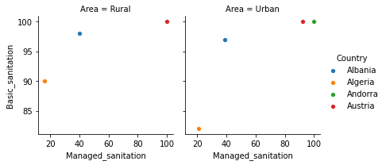

```python
g=sns.FacetGrid(data=frame, hue= 'Country', col='Area')
g.map_dataframe(sns.scatterplot, 'Managed_sanitation', 'Basic_sanitation')
g.add_legend()
```

*Non è abbastanza funzionale a fornire una comunicazione visiva efficace e comprensibile*

Grafico: *BAR CHART*

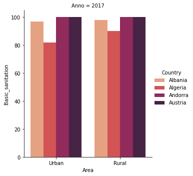

```python
sns.catplot(data = frame, x = 'Area', order = ['Urban', 'Rural'], y = 'Basic_sanitation', col= 'Anno', hue= 'Country', kind= 'bar', palette= 'rocket_r', aspect=.9)
plt.show()
```

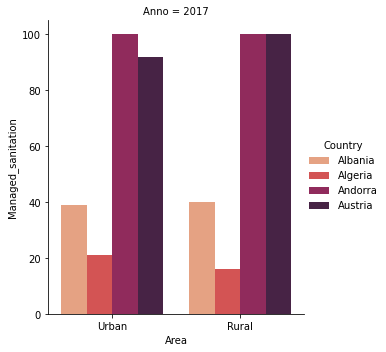

```python
sns.catplot(data = frame, x = 'Area', order = ['Urban', 'Rural'], y = 'Managed_sanitation', col= 'Anno', hue= 'Country', kind= 'bar', palette= 'rocket_r', aspect=.9)
plt.show()
```

Miglior grafico per una buona comunicazione visuale

Grafico: *BOXPLOT*

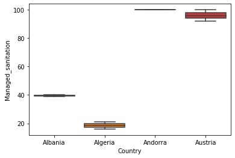

```python
sns.boxplot(data=frame, x='Country', y='Managed_sanitation')  # visualizzazione più compatta
```

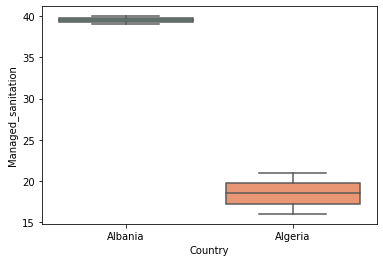

```python
g= sns.boxplot(x='Country', y='Managed_sanitation', palette='Set2',
              data=frame.loc[frame['Managed_sanitation'] <90])  #miglioro la visualizzazione selezionando solo i valori < 90
```

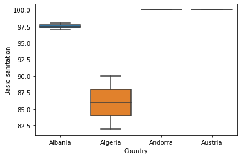

```python
sns.boxplot(data=frame, x='Country', y='Basic_sanitation')
```

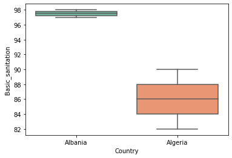

```python
g= sns.boxplot(x='Country', y='Basic_sanitation', palette='Set2',
              data=frame.loc[frame['Basic_sanitation'] <100])  # miglioro la visualizzazione selezionando solo i valori < 100 così da vedere gli Stati più omogenei
```

Sicuramente non è soddisfacente neanche questa rappresentazione grafica per i pochi punti che si vuole rappresentare

### Definire le informazioni grafiche

- QUALI INFORMAZIONI VUOLE TRASMETTERE QUESTO GRAFICO A BARRE?
- E' COMPRENSIBILE COME PRESENTAZIONE PUBBLICA?

Il grafico *Bar Chart* definisce la relazione tra due variabili x e y, e vuole mostrare quale degli Stati selezionati ha maggiori possibilità di usufuire dei servizi sanitari. Le condizioni sono le due diverse *aree di residenza*, fattori determinanti per l'accesso ai servizi.

### Motivare la scelta della forma grafica

Da un punto di vista statistico/analitico il grafico a barre è maggiormente efficiente per rappresentare questa prima analisi, in quanto sia nel primo che nel secondo bar chart, la variabile usata come *variabile dipendente* (e quindi posizionata sull'asse delle y), è una variabile cardinale discreta (formata da numeri interi), ma la *variabile* scelta come *indipendente* (rappresentata dai valori della x), è una variabile categoriale o nominale, fornisce un'informazione in base alle due modalità di cui è composta (Urban e Rural) e rappresenta una stringa, per cui non era opportuno optare per un grafico che richiedesse entrambe le variabili cardinali (non è possibile convertire stringhe in float, es. funzione jointplot).

Da un punto di vista visivo, il bar chart permette di avere una visualizzazione migliore e più intuitiva. In questo caso, essendoci pochi dati, la diversa altezza delle barre favorisce la comprensione del grafico perchè mette a confronti gli Stati e le differenze sono ben distinguibili, piuttosto che avere pochi punti molto dispersi tra loro.

### Evidenziare i benefici della comunicazione visuale

Comunicare attraverso rappresentazioni visive permette di meglio cogliere le *informazioni*, di evidenziare le differenze o le somiglianze. Il lettore preferirà osservare una bella tipologia di grafico colorato e ordinato piuttosto che leggere e dare la giusta interpretazione ai dati (soprattutto se statistici sono necessarie delle conoscenze più settoriali). Una buona comunicazione visuale imprime direttamente nell'occhio di chi sta osservando i concetti chiave per comprendere i significati, i *risultati dell'analisi* e ciò che si vuole raccontare attraverso essa, catturandone l'attenzione visiva.

### Considerazioni e narrazioni grafiche (*STORYTELLING*), attraverso i grafici

Ho utilizzato una palette di colori di diverse gradazioni per distinguere tra loro gli stati nell'anno 2017. I colori più scuri (le due tonalità di viola) sono riferiti ai due Stati con una più elevata percentuale di popolazione che fa uso dei servizi sanitari; i colori più chiari (le due tonalità di rosa) riguardano invece gli altri due stati i quali fanno un utilizzo più limitato.

Tale rappresentazione porta a ragionare sul fatto che ciò dipende dai fattori economici presenti in ciascun Stato, in particolare dal reddito o dal PIL. Su questa base dunque è possibile suddividere questo ristretto gruppo di Stati in Stati più ricchi e Stati più poveri.

### Impostare un buon ragionamento sulla comunicazione visiva

Nell'insieme, guardando ai dei due grafici bar chart, si evince una maggiore propensione al consumo, da parte di questi Stati, di *servizi igienico-sanitari di base*, primari e gratuiti, messi a disposizione per ogni Stato per eventuali esigenze primarie della popolazione, piuttosto che di *servizi gestiti in sicurezza*, più sofisticati e evidentemente meno accessibili a tutti perchè costosi.

### Presentare i risultati

- E' PRESENTE UNA LOGICA CHIARA NELLA PRESENTAZIONE DEI RISULTATI?
- SONO LEGGIBILI?

I risultati sono di facile comprensione e leggibili poichè sono state presentate tutte le indicazioni necessarie al fine di comprendere i significati dell'analisi.

E' presente l'anno cui si sta facendo riferimento (2017), la variabile indipendente (x) che determina la variazione della variabile dipendente (y) e la legenda con le diverse gradazioni di colori che ci mostra i 4 Stati (Country) cui ci si riferisce.

**ULTERIORI ANALISI**

```python
new1_key        # riprendo il Dataframe in formato chiave:valore per eseguire una nuova analisi
```

|  | Years | Sanitation | Residence | Nazioni | Valore |
| --- | --- | --- | --- | --- | --- |
| 0 | 2017 | Population using at least basic sanitation se... | Total | Albania | 98 |
| 1 | 2017 | Population using at least basic sanitation se... | Urban | Albania | 98 |
| 2 | 2017 | Population using at least basic sanitation se... | Rural | Albania | 97 |
| 3 | 2017 | Population using safely managed sanitation se... | Total | Albania | 40 |
| 4 | 2017 | Population using safely managed sanitation se... | Urban | Albania | 40 |
| ... | ... | ... | ... | ... | ... |
| 3991 | 2000 | Population using at least basic sanitation se... | Urban | United Republic of Tanzania | 11 |
| 3992 | 2000 | Population using at least basic sanitation se... | Rural | United Republic of Tanzania | 3 |
| 3993 | 2000 | Population using safely managed sanitation se... | Total | United Republic of Tanzania | 4 |
| 3994 | 2000 | Population using safely managed sanitation se... | Urban | United Republic of Tanzania | 9 |
| 3995 | 2000 | Population using safely managed sanitation se... | Rural | United Republic of Tanzania | 2 |

3996 rows × 5 columns

**FUNZIONE ILOC**

```python
ultimi36 = new1_key.iloc[-36:]        # seleziono attraverso gli indici le ultime 36 righe del dataframe per eseguire un'ulteriore analisi
print("Ultimi36 \n", ultimi36)
```

```
Ultimi36
      Years                                         Sanitation Residence  \
3960  2005   Population using at least basic sanitation se...     Total
3961  2005   Population using at least basic sanitation se...     Urban
3962  2005   Population using at least basic sanitation se...     Rural
3963  2005   Population using safely managed sanitation se...     Total
3964  2005   Population using safely managed sanitation se...     Urban
3965  2005   Population using safely managed sanitation se...     Rural
3966  2004   Population using at least basic sanitation se...     Total
3967  2004   Population using at least basic sanitation se...     Urban
3968  2004   Population using at least basic sanitation se...     Rural
3969  2004   Population using safely managed sanitation se...     Total
3970  2004   Population using safely managed sanitation se...     Urban
3971  2004   Population using safely managed sanitation se...     Rural
3972  2003   Population using at least basic sanitation se...     Total
```

[output cut: 61 more lines]

Dalla selezione di righe risulta una sola nazione, "*United Republic of Tanzania*"

Voglio rappresentare l'andamento che ha avuto nel tempo (dall'anno 2000 al 2005)

Grafico: *SWARMPLOT*

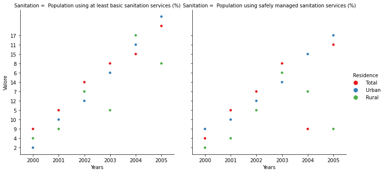

```python
g = sns.catplot(x='Years', y='Valore', data=ultimi36, hue='Residence', col='Sanitation', kind='swarm', palette='Set1')
```

**ULTERIORI RAPPRESENTAZIONI GRAFICHE**

[output not shown]

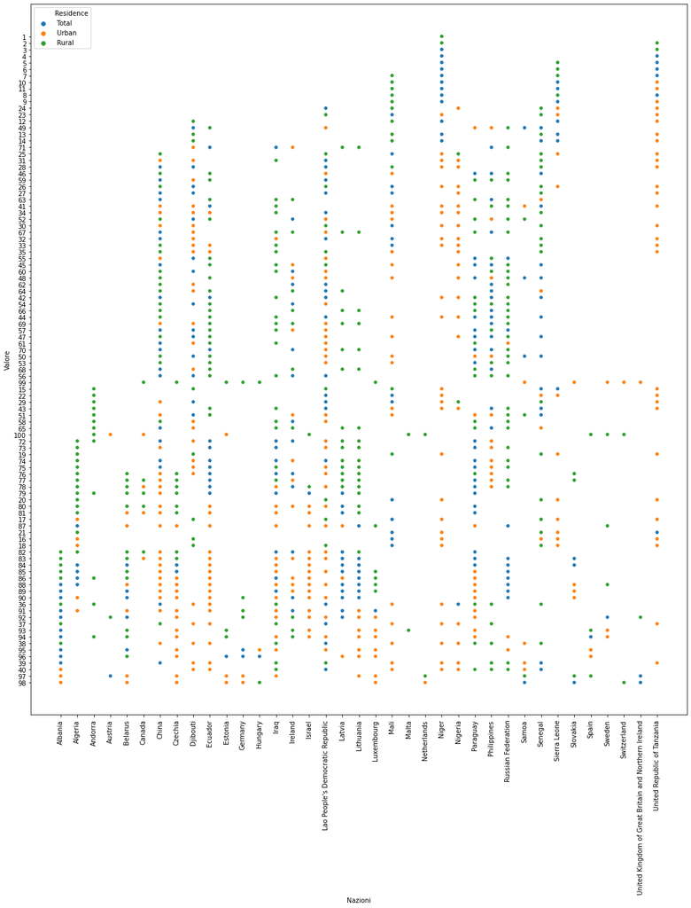

```python
fig,ax = plt.subplots(figsize=(18,20))
fig = sns.scatterplot(x='Nazioni', y='Valore', data=new1_key, hue='Residence');
plt.xticks(rotation=90)
                              # altre prove di rappresentazioni visive considerando tutti gli Stati
```

[output not shown]

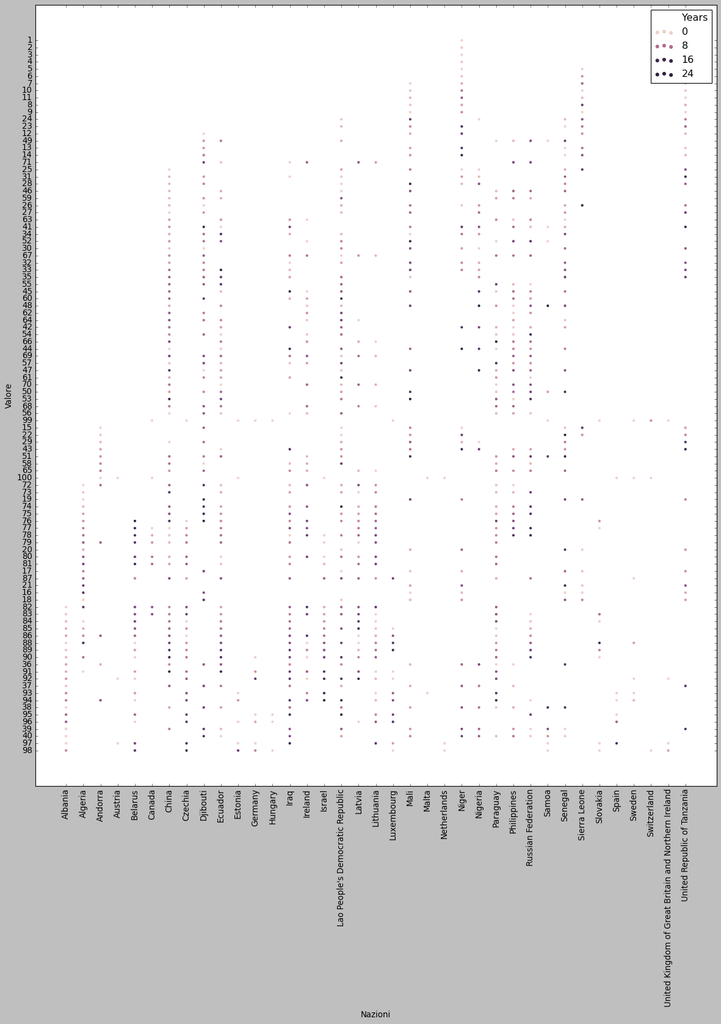

```python
fig,ax = plt.subplots(figsize=(18,20))
fig = sns.scatterplot(x='Nazioni', y='Valore', hue='Years', data=new1_key)
plt.xticks(rotation=90)
```